# sentiment-analysis-on-amazon-reviews

**No warnings**

```python
!pip install shutup
```

```python
import shutup; shutup.please()
```

**Kaggle API token for Google Colab**

**The following steps are only for running notebook in Google Colab Environment**

```python
#!pip install kaggle
```

```python
#!mkdir ~/.kaggle
#!cp /content/kaggle.json ~/.kaggle/kaggle.json
#!chmod 600 /root/.kaggle/kaggle.json
```

```python
#!kaggle competitions download nlp-getting-started
#!unzip *.zip
```

# Importing Required Libraries

```python
import numpy as np
import pandas as pd

from sklearn.preprocessing import LabelEncoder
from sklearn.model_selection import cross_val_score, GridSearchCV, cross_validate
from sklearn.linear_model import LogisticRegression
from sklearn.ensemble import RandomForestClassifier
from sklearn.svm import SVC
from sklearn.tree import DecisionTreeClassifier
from sklearn.naive_bayes import MultinomialNB

import nltk
from nltk.corpus import stopwords
from nltk.sentiment import SentimentIntensityAnalyzer
from textblob import Word, TextBlob
from sklearn.feature_extraction.text import TfidfVectorizer
from sklearn.feature_extraction.text import CountVectorizer

import matplotlib.pyplot as plt
import plotly.graph_objs as go
import plotly.io as pio
from wordcloud import WordCloud
```

# Loading the data

```python
df = pd.read_excel("/kaggle/input/amazon-reviews/amazon.xlsx")
df.head()
```

|  | Star | HelpFul | Title | Review |
| --- | --- | --- | --- | --- |
| 0 | 5 | 0 | looks great | Happy with it |
| 1 | 5 | 0 | Pattern did not align between the two panels. | Good quality material however the panels are m... |
| 2 | 5 | 0 | Imagery is stretched. Still fun. | Product was fun for bedroom windows.<br />Imag... |
| 3 | 5 | 0 | Que se ven elegantes muy finas | Lo unico que me gustaria es que sean un poco ... |
| 4 | 5 | 0 | Wow great purchase | Great bang for the buck I can't believe the qu... |

# Data Preprocessing

**Checking for nulls in the dataset**

```python
df.isnull().sum()
```

```
Star        0
HelpFul     0
Title      52
Review     18
dtype: int64
```

**18 reviews are null so we have to drop them**

We will not touch the rest of the columns as we are primarily focussing on Sentiment Analysis in this notebook.

```python
df.dropna(subset=['Review'], inplace=True)
df.isnull().sum()
```

```
Star        0
HelpFul     0
Title      43
Review      0
dtype: int64
```

**Initializing Stopwords using NLTK**

```python
nltk.download('stopwords')
sw = stopwords.words('english')
```

**Text Prepocessing**

The following preprocessing has been applied to the "Review" column.

1. Lowercasing
2. Non-word character Removal
3. Digits Removal
4. Stop word removal

```python
df['Review'] = df['Review'].str.lower()
df['Review'] = df['Review'].str.replace('[^\w\s]', '')
df['Review'] = df['Review'].str.replace('\d', '')
df['Review'] = df['Review'].apply(lambda x: " ".join(x for x in str(x).split() if x not in sw))
```

**Finding out the rare words and storing them separately in a temporary dataframe**

```python
temp_df = pd.Series(' '.join(df['Review']).split()).value_counts()
temp_df
```

```
curtains          1891
love              1312
room              1116
like              1037
beautiful          943
                  ...
mold                 1
wat                  1
curtainsdrapes       1
ambesome             1
studioliving         1
Length: 6698, dtype: int64
```

```python
drops = temp_df[temp_df <= 1]
```

```python
df['Review'] = df['Review'].apply(lambda x: " ".join(x for x in x.split() if x not in drops))
```

**Lemmatization**

```python
!unzip /usr/share/nltk_data/corpora/wordnet.zip -d /usr/share/nltk_data/corpora/
```

```
Archive:  /usr/share/nltk_data/corpora/wordnet.zip
replace /usr/share/nltk_data/corpora/wordnet/lexnames? [y]es, [n]o, [A]ll, [N]one, [r]ename: ^C
```

```python
nltk.download('wordnet')
nltk.download('omw-1.4')
```

```
True
```

```python
df['Review'] = df['Review'].apply(lambda x: " ".join([Word(word).lemmatize() for word in x.split()]))
df.head()
```

|  | Star | HelpFul | Title | Review |
| --- | --- | --- | --- | --- |
| 0 | 5 | 0 | looks great | happy |
| 1 | 5 | 0 | Pattern did not align between the two panels. | good quality material however panel |
| 2 | 5 | 0 | Imagery is stretched. Still fun. | product fun bedroom windowsbr imagery bit stre... |
| 3 | 5 | 0 | Que se ven elegantes muy finas | lo que e que un poco ma |
| 4 | 5 | 0 | Wow great purchase | great bang buck cant believe quality material ... |

# Exploratory Data Analysis

Exploratory Data Analysis (EDA) in Natural Language Processing (NLP) is the process of visually and statistically analyzing a dataset containing text data to uncover patterns, trends, anomalies, and insights. EDA helps NLP practitioners and data scientists better understand the textual data they are working with before diving into more advanced NLP tasks such as text classification, **sentiment analysis**, topic modeling, or machine translation.

**Extracting Term Frequencies**

Term frequency (TF) is a numerical statistic used in natural language processing and text analysis to quantify how frequently a term (word or phrase) appears in a document or a corpus of documents. It's a fundamental concept in text mining and information retrieval. Term frequency is typically calculated using the following formula:

## $TF(t,d) = \frac{Number \ of \ times \ term \ t \ appears \ in \ document \ d}{Total \ number \ of \ terms \ in \ document \ d}$

```python
tf = df["Review"].apply(lambda x: pd.value_counts(x.split(" "))).sum(axis=0).reset_index()
tf.head()
```

|  | index | 0 |
| --- | --- | --- |
| 0 | happy | 196.0 |
| 1 | good | 535.0 |
| 2 | quality | 889.0 |
| 3 | material | 565.0 |
| 4 | however | 78.0 |

```python
tf.columns = ["words", "tf"]
```

```python
tf.sort_values("tf", ascending=False)
```

|  | words | tf |
| --- | --- | --- |
| 58 | curtain | 2588.0 |
| 35 | look | 1531.0 |
| 108 | love | 1453.0 |
| 92 | room | 1129.0 |
| 152 | like | 1053.0 |
| ... | ... | ... |
| 1940 | nail | 2.0 |
| 1941 | salon | 2.0 |
| 1944 | write | 2.0 |
| 1947 | colorsbr | 2.0 |
| 2726 | miran | 2.0 |

2727 rows × 2 columns

## **Plotting Term Frequencies**

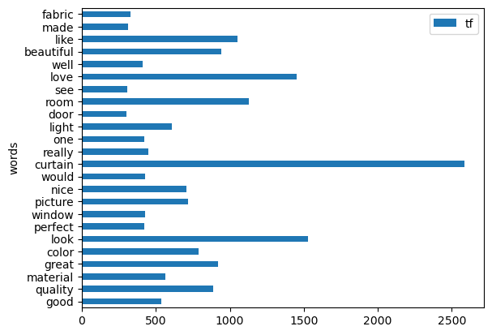

```python
tf[tf["tf"] > 300].plot.barh(x="words", y="tf")
plt.show()
```

```python
text = " ".join(i for i in df.Review)
```

## **WordCloud**

A word cloud is a visual representation of text data, where the size of each word is proportional to its frequency or importance in a given corpus of text. In a word cloud, more frequent words are typically displayed in a larger font size, making it easy to see which words are most prominent in the text.

Word clouds are often used for data visualization and can help quickly identify the most significant terms or themes in a body of text. They are commonly used in various fields, including natural language processing, text analysis, marketing, and content summarization.

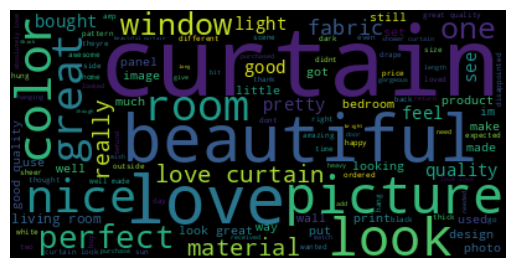

```python
wordcloud = WordCloud().generate(text)
plt.imshow(wordcloud, interpolation="bilinear")
plt.axis("off")
plt.show()
```

# Sentiment Analysis

```python
df["Review"].head()
```

```
0                                                happy
1                  good quality material however panel
2    product fun bedroom windowsbr imagery bit stre...
3                              lo que e que un poco ma
4    great bang buck cant believe quality material ...
Name: Review, dtype: object
```

## **Initializing VADER SIA**

VADER (Valence Aware Dictionary and sEntiment Reasoner) is a lexicon and rule-based sentiment analysis tool specifically designed for analyzing the sentiment of text in the context of social media and informal online text. It was developed by researchers at the Georgia Institute of Technology.

**The output will include scores for positivity, neutrality, and negativity, as well as a compound score that summarizes the overall sentiment of the text.**

```python
nltk.download('vader_lexicon')
```

```
True
```

```python
sia = SentimentIntensityAnalyzer()
sia.polarity_scores("The film was awesome")
```

```
{'neg': 0.0, 'neu': 0.423, 'pos': 0.577, 'compound': 0.6249}
```

```python
sia.polarity_scores("I liked this music but it is not good as the other one")
```

```
{'neg': 0.207, 'neu': 0.666, 'pos': 0.127, 'compound': -0.298}
```

```python
df["Review"][0:10].apply(lambda x: sia.polarity_scores(x))
```

```
0    {'neg': 0.0, 'neu': 0.0, 'pos': 1.0, 'compound...
1    {'neg': 0.0, 'neu': 0.58, 'pos': 0.42, 'compou...
2    {'neg': 0.0, 'neu': 0.625, 'pos': 0.375, 'comp...
3    {'neg': 0.0, 'neu': 1.0, 'pos': 0.0, 'compound...
4    {'neg': 0.0, 'neu': 0.495, 'pos': 0.505, 'comp...
5    {'neg': 0.0, 'neu': 1.0, 'pos': 0.0, 'compound...
6    {'neg': 0.0, 'neu': 0.594, 'pos': 0.406, 'comp...
7    {'neg': 0.0, 'neu': 0.578, 'pos': 0.422, 'comp...
8    {'neg': 0.0, 'neu': 1.0, 'pos': 0.0, 'compound...
9    {'neg': 0.0, 'neu': 0.772, 'pos': 0.228, 'comp...
Name: Review, dtype: object
```

```python
df["Review"][0:10].apply(lambda x: sia.polarity_scores(x)["compound"])
```

```
0    0.5719
1    0.4404
2    0.7184
3    0.0000
4    0.9042
5    0.0000
6    0.6249
7    0.9080
8    0.0000
9    0.7096
Name: Review, dtype: float64
```

```python
df["polarity_score"] = df["Review"].apply(lambda x: sia.polarity_scores(x)["compound"])
```

## **Feature Engineering**

Adding Sentiments from the generated scores.

```python
df["Review"][0:10].apply(lambda x: "pos" if sia.polarity_scores(x)["compound"] > 0 else "neg")
```

```
0    pos
1    pos
2    pos
3    neg
4    pos
5    neg
6    pos
7    pos
8    neg
9    pos
Name: Review, dtype: object
```

```python
df["sentiment_label"] = df["Review"].apply(lambda x: "pos" if sia.polarity_scores(x)["compound"] > 0 else "neg")
df["sentiment_label"].value_counts()
```

```
pos    4764
neg     829
Name: sentiment_label, dtype: int64
```

```python
df.head()
```

|  | Star | HelpFul | Title | Review | polarity_score | sentiment_label |
| --- | --- | --- | --- | --- | --- | --- |
| 0 | 5 | 0 | looks great | happy | 0.5719 | pos |
| 1 | 5 | 0 | Pattern did not align between the two panels. | good quality material however panel | 0.4404 | pos |
| 2 | 5 | 0 | Imagery is stretched. Still fun. | product fun bedroom windowsbr imagery bit stre... | 0.7184 | pos |
| 3 | 5 | 0 | Que se ven elegantes muy finas | lo que e que un poco ma | 0.0000 | neg |
| 4 | 5 | 0 | Wow great purchase | great bang buck cant believe quality material ... | 0.9042 | pos |

```python
df = df.sample(frac = 1)
df.head()
```

|  | Star | HelpFul | Title | Review | polarity_score | sentiment_label |
| --- | --- | --- | --- | --- | --- | --- |
| 3937 | 5 | 0 | Awesome Curtains! | like daughter room ocean took daughter bifold ... | 0.7430 | pos |
| 208 | 5 | 1 | It's a keeper. | loving curtain | 0.5994 | pos |
| 929 | 5 | 0 | Looks great in the babies' nursery! | look great fit window baby nursery perfectly | 0.8957 | pos |
| 3590 | 4 | 0 | Feels cheap | feel cheap price | 0.0000 | neg |
| 5103 | 4 | 0 | Quality | love art everything absolutely perfect thank l... | 0.9448 | pos |

```python
df["sentiment_label"] = LabelEncoder().fit_transform(df["sentiment_label"])
```

```python
df.head()
```

|  | Star | HelpFul | Title | Review | polarity_score | sentiment_label |
| --- | --- | --- | --- | --- | --- | --- |
| 3937 | 5 | 0 | Awesome Curtains! | like daughter room ocean took daughter bifold ... | 0.7430 | 1 |
| 208 | 5 | 1 | It's a keeper. | loving curtain | 0.5994 | 1 |
| 929 | 5 | 0 | Looks great in the babies' nursery! | look great fit window baby nursery perfectly | 0.8957 | 1 |
| 3590 | 4 | 0 | Feels cheap | feel cheap price | 0.0000 | 0 |
| 5103 | 4 | 0 | Quality | love art everything absolutely perfect thank l... | 0.9448 | 1 |

```python
y = df["sentiment_label"]
X = df["Review"]
```

## **Application of `CountVectorizer()`**

```python
vectorizer = CountVectorizer()
X_count = vectorizer.fit_transform(X)
```

```python
vectorizer.get_feature_names_out()[10:15]
```

```
array(['accessory', 'accommodate', 'account', 'accurate', 'across'],
      dtype=object)
```

## **Application of TF-IDF and N-Gram**

An n-gram is a contiguous sequence of n items (or words) from a given sample of text or speech. N-grams are used in various natural language processing (NLP) and text analysis tasks to capture and represent the relationship between words or characters within a text. The "n" in n-gram refers to the number of items in each sequence.

**Within Sentiment Analysis -** N-grams can be used to extract and analyze phrases or idioms that are indicative of sentiment in text data.

```python
tf_idf_word_vectorizer = TfidfVectorizer()
X_tf_idf_word = tf_idf_word_vectorizer.fit_transform(X)
```

```python
tf_idf_ngram_vectorizer = TfidfVectorizer(ngram_range=(2, 3))
X_tf_idf_ngram = tf_idf_ngram_vectorizer.fit_transform(X)
```

# Sentiment Modelling

**Order of Execution**

1. Model Initialization
2. Model Fitting on our training data
3. Model Cross-Validation with 5 folds
4. Testing Model Generalizability

**What is Model Generalizability ?**

Model generalization is a critical concept in machine learning and is closely related to a model's ability to perform well on unseen or new data. When a machine learning model generalizes well, it means that it has learned to capture the underlying patterns in the training data and can apply that knowledge to make accurate predictions or classifications on data it hasn't encountered before. Generalization is a fundamental goal because it indicates that a model has learned useful, transferable knowledge rather than memorizing the training data.

## **MultiNomial Naive Bayes**

```python
nb_model = MultinomialNB().fit(X_tf_idf_word, y)
nb_score = cross_val_score(nb_model,
                X_tf_idf_word,
                y,
                scoring="accuracy",
                cv=5).mean()
print(nb_score)
```

```
0.8646526655380076
```

**Testing Generalizability**

```python
# introducing a positive review
new_review = pd.Series("this product is amazing")

# vectorize the our review
new_review = TfidfVectorizer().fit(X).transform(new_review)

# predict the sentiment of our review
nb_model.predict(new_review)
```

```
array([1])
```

```python
# introducing a negative review
new_review = pd.Series("my experience was horrible")

# vectorize the our review
new_review = TfidfVectorizer().fit(X).transform(new_review)

# predict the sentiment of our review
nb_model.predict(new_review)
```

```
array([0])
```

## **Logistic Regressor**

```python
lr_model = LogisticRegression().fit(X_tf_idf_word, y)
lr_score = cross_val_score(lr_model,
                X_tf_idf_word,
                y,
                scoring="accuracy",
                cv=5).mean()
print(lr_score)
```

```
0.8966579859029513
```

**Testing Generalizability**

```python
# introducing a positive review
new_review = pd.Series("this product is amazing")

# vectorize the our review
new_review = TfidfVectorizer().fit(X).transform(new_review)

# predict the sentiment of our review
lr_model.predict(new_review)
```

```
array([1])
```

```python
# introducing a negative review
new_review = pd.Series("my experience was horrible")

# vectorize the our review
new_review = TfidfVectorizer().fit(X).transform(new_review)

# predict the sentiment of our review
lr_model.predict(new_review)
```

```
array([0])
```

## **Support Vector Model**

```python
svc_model = SVC().fit(X_tf_idf_word, y)
svc_score = cross_val_score(svc_model,
                X_tf_idf_word,
                y, scoring = "accuracy",
                cv=5, n_jobs=-1).mean()
print(svc_score)
```

```
0.9054194823195385
```

```python
# introducing a positive review
new_review = pd.Series("this product is amazing")

#vectorize the our review
new_review = TfidfVectorizer().fit(X).transform(new_review)

# predict the sentiment of our review
svc_model.predict(new_review)
```

```
array([1])
```

```python
# introducing a negative review
new_review = pd.Series("my experience was horrible")

# vectorize the our review
new_review = TfidfVectorizer().fit(X).transform(new_review)

# predict the sentiment of our review
svc_model.predict(new_review)
```

```
array([0])
```

## **Decision Tree Model**

```python
dc_model = DecisionTreeClassifier().fit(X_tf_idf_word, y)
dc_score = cross_val_score(dc_model,
                X_tf_idf_word,
                y, scoring = "accuracy",
                cv=5, n_jobs=-1).mean()
print(dc_score)
```

```
0.918112901085655
```

**Model Generalizability**

```python
# introducing a positive review
new_review = pd.Series("this product is amazing")

#vectorize the our review
new_review = TfidfVectorizer().fit(X).transform(new_review)

# predict the sentiment of our review
dc_model.predict(new_review)
```

```
array([1])
```

```python
# introducing a negative review
new_review = pd.Series("my experience was horrible")

# vectorize the our review
new_review = TfidfVectorizer().fit(X).transform(new_review)

# predict the sentiment of our review
dc_model.predict(new_review)
```

```
array([0])
```

## **Random Forest Model**

```python
rf_model = RandomForestClassifier().fit(X_tf_idf_word, y)
rf_score = cross_val_score(rf_model,
                X_tf_idf_word,
                y, scoring = "accuracy",
                cv=5, n_jobs=-1).mean()
print(rf_score)
```

```
0.9182919518289555
```

**Testing Generalizability**

```python
# introducing a positive review
new_review = pd.Series("this product is amazing")

#vectorize the our review
new_review = TfidfVectorizer().fit(X).transform(new_review)

# predict the sentiment of our review
rf_model.predict(new_review)
```

```
array([1])
```

```python
# introducing a negative review
new_review = pd.Series("my experience was horrible")

# vectorize the our review
new_review = TfidfVectorizer().fit(X).transform(new_review)

# predict the sentiment of our review
lr_model.predict(new_review)
```

```
array([0])
```

**Printing all Model Scores**

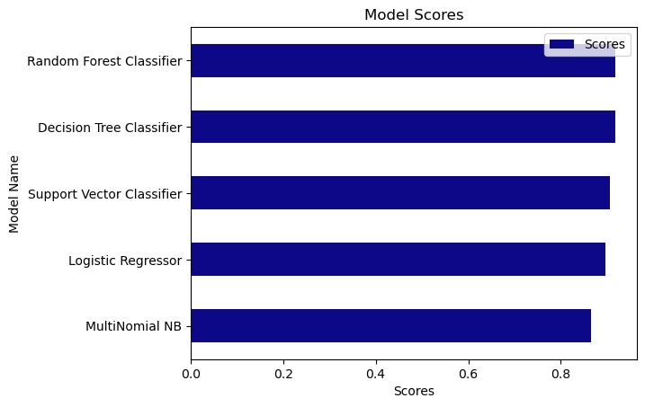

```python
scores = {
    'Model Name' : ["MultiNomial NB", "Logistic Regressor", "Support Vector Classifier", "Decision Tree Classifier", "Random Forest Classifier"],
    'Scores' : [nb_score, lr_score, svc_score, dc_score, rf_score]
}

scores_df = pd.DataFrame(scores)

scores_df.plot(x='Model Name', y='Scores', kind='barh',colormap = 'plasma')

plt.xlabel('Scores')
plt.ylabel('Model Name')
plt.title('Model Scores')

plt.show()
```

# Hyperparameter tuning

As our Random Forest Model gives us the best accuracy score, we will tune it further.

```python
rf_tuned_model = RandomForestClassifier(random_state=42)
```

```python
%%time
rf_params = {"max_depth": [8, None],
             "max_features": [7, "sqrt"],
             "min_samples_split": [2, 5, 8],
             "n_estimators": [100, 200]
             }

rf_best_grid = GridSearchCV(rf_tuned_model,
                            rf_params,
                            cv=5,
                            n_jobs=-1,
                            verbose=1).fit(X_count, y)
```

```
Fitting 5 folds for each of 24 candidates, totalling 120 fits
CPU times: user 5.04 s, sys: 47.2 ms, total: 5.08 s
Wall time: 1min 20s
```

```python
rf_best_grid.best_params_
```

```
{'max_depth': None,
 'max_features': 'sqrt',
 'min_samples_split': 2,
 'n_estimators': 200}
```

**Setting models with above found parameters**

```python
rf_final = rf_tuned_model.set_params(**rf_best_grid.best_params_, random_state=42).fit(X_count, y)
```

**Final Score**

```python
cross_val_score(rf_final, X_count, y, cv=5, n_jobs=-1).mean()
```

```
0.9286626668009547
```

# What If Section ?

**Suppose you wanted to check how different methods such as the ones listed below affect the final scores on our best model**

1. Count Vectorization
2. TF-IDF (Word-Level Granularity)
3. TF-IDF (N-Gram Level Granularity)

```python
%%time
def score(method_list):
    scores = []
    for method in method_list:
        rf_model = RandomForestClassifier().fit(method, y)
        scores.append(cross_val_score(rf_model, method, y, cv=5, n_jobs=-1).mean())

    scores_df = pd.DataFrame({"Methods": ["Count Vectorization", "TF-IDF Word-Level", "TF-IDF N-Gram"],
                             "Scores": scores})

    trace1 = go.Bar(
                    y = scores_df["Methods"],
                    x = scores_df["Scores"],
                    name = "Accuracy Plot",
                    text=[round(i,5) for i in scores_df['Scores']],
                    marker = dict(color = ['#2ECC71','#34495E','#D0D3D4'],
                                 line=dict(color='rgb(0,0,0)',width=1.5)),
        orientation='h', textposition = 'inside'
    )
    data = [trace1]
    layout = go.Layout(barmode = "group",
                       title={'text': "Scores" ,
                                 'y':0.9,
                                 'x':0.5,
                                 'xanchor': 'center',
                                 'yanchor': 'top'},
                          template='plotly_dark')
    fig = go.Figure(data = data, layout = layout)
    pio.show(fig)

method_list = [X_count, X_tf_idf_word, X_tf_idf_ngram]
score(method_list)
```

[interactive chart not shown]

```
CPU times: user 18.2 s, sys: 63.7 ms, total: 18.2 s
Wall time: 3min 8s
```

## Inference

**Hence we deduce that Count Vectorization prior to our Random Forest model yields the highest score.**